# Self-Driving Car Engineer Nanodegree

## Project: Build a Traffic Sign Recognition Classifier

In this notebook, a template is provided for you to implement your functionality in stages, which is required to successfully complete this project. If additional code is required that cannot be included in the notebook, be sure that the Python code is successfully imported and included in your submission if necessary.

In addition to implementing code, there is a writeup to complete. The writeup should be completed in a separate file, which can be either a markdown file or a pdf document. There is a [write up template](https://github.com/udacity/CarND-Traffic-Sign-Classifier-Project/blob/master/writeup_template.md) that can be used to guide the writing process. Completing the code template and writeup template will cover all of the [rubric points](https://review.udacity.com/#!/rubrics/481/view) for this project.

The [rubric](https://review.udacity.com/#!/rubrics/481/view) contains "Stand Out Suggestions" for enhancing the project beyond the minimum requirements. The stand out suggestions are optional. If you decide to pursue the "stand out suggestions", you can include the code in this Ipython notebook and also discuss the results in the writeup file.

> **Note:** Code and Markdown cells can be executed using the **Shift + Enter** keyboard shortcut. In addition, Markdown cells can be edited by typically double-clicking the cell to enter edit mode.

## Step 0: Load The Data

```python
# Load pickled data
import pickle

# TODO: Fill this in based on where you saved the training and testing data

training_file   = './traffic-signs-data/train.p'
validation_file = './traffic-signs-data/valid.p'
testing_file    = './traffic-signs-data/test.p'

with open(training_file, mode='rb') as f:
    train = pickle.load(f)
with open(validation_file, mode='rb') as f:
    valid = pickle.load(f)
with open(testing_file, mode='rb') as f:
    test = pickle.load(f)

X_train, y_train = train['features'], train['labels']
X_valid, y_valid = valid['features'], valid['labels']
X_test, y_test = test['features'], test['labels']
```

## Step 1: Dataset Summary & Exploration

The pickled data is a dictionary with 4 key/value pairs:

- `'features'` is a 4D array containing raw pixel data of the traffic sign images, (num examples, width, height, channels).
- `'labels'` is a 1D array containing the label/class id of the traffic sign. The file `signnames.csv` contains id -> name mappings for each id.
- `'sizes'` is a list containing tuples, (width, height) representing the original width and height the image.
- `'coords'` is a list containing tuples, (x1, y1, x2, y2) representing coordinates of a bounding box around the sign in the image. **THESE COORDINATES ASSUME THE ORIGINAL IMAGE. THE PICKLED DATA CONTAINS RESIZED VERSIONS (32 by 32) OF THESE IMAGES**

Complete the basic data summary below. Use python, numpy and/or pandas methods to calculate the data summary rather than hard coding the results. For example, the [pandas shape method](http://pandas.pydata.org/pandas-docs/stable/generated/pandas.DataFrame.shape.html) might be useful for calculating some of the summary results.

### Provide a Basic Summary of the Data Set Using Python, Numpy and/or Pandas

```python
### Replace each question mark with the appropriate value.
### Use python, pandas or numpy methods rather than hard coding the results

# TODO: Number of training examples
n_train = X_train.shape[0] # shape is a tuple: (num_samples, width, height, channel)

# TODO: Number of validation examples
n_validation = X_valid.shape[0]

# TODO: Number of testing examples.
n_test = X_test.shape[0]

# TODO: What's the shape of an traffic sign image?
image_shape = X_train[0].shape

# TODO: How many unique classes/labels there are in the dataset.
n_classes = len(set(y_train))

print("Number of training examples =", n_train)
print("Number of testing examples =", n_test)
print("Image data shape =", image_shape)
print("Number of classes =", n_classes)
```

```
Number of training examples = 34799
Number of testing examples = 12630
Image data shape = (32, 32, 3)
Number of classes = 43
```

### Include an exploratory visualization of the dataset

Visualize the German Traffic Signs Dataset using the pickled file(s). This is open ended, suggestions include: plotting traffic sign images, plotting the count of each sign, etc.

The [Matplotlib](http://matplotlib.org/) [examples](http://matplotlib.org/examples/index.html) and [gallery](http://matplotlib.org/gallery.html) pages are a great resource for doing visualizations in Python.

**NOTE:** It's recommended you start with something simple first. If you wish to do more, come back to it after you've completed the rest of the sections. It can be interesting to look at the distribution of classes in the training, validation and test set. Is the distribution the same? Are there more examples of some classes than others?

[figure not shown]

```python
### Data exploration visualization code goes here.
### Feel free to use as many code cells as needed.
import matplotlib.pyplot as plt
import numpy as np
import random

# Visualizations will be shown in the notebook.
%matplotlib inline

ROW = 4
COL = 6

def plot_data(data, label, channel=None, row=ROW, col=COL):
    fig, axes = plt.subplots(row, col, figsize=(12, 10))
    fig.subplots_adjust(hspace=0.01, wspace=0.1)
    axes = axes.flatten()
    for i in range(row * col):
        index = random.randint(0, len(data))
        if channel == 'gray':
            gray_image = data[index].squeeze()
            axes[i].imshow(gray_image, cmap='gray')
        else:
            axes[i].imshow(data[index])
        axes[i].set_title(label[index])
        axes[i].set_axis_off()

plot_data(X_train, y_train)
```

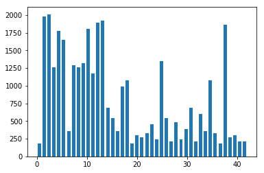

```python
# histogram of label frequency (once again, before data augmentation)
hist, bins = np.histogram(y_train, bins=n_classes)
width = 0.7 * (bins[1] - bins[0])
center = (bins[:-1] + bins[1:]) / 2
plt.bar(center, hist, align='center', width=width)
plt.show()
```

## Step 2: Design and Test a Model Architecture

Design and implement a deep learning model that learns to recognize traffic signs. Train and test your model on the [German Traffic Sign Dataset](http://benchmark.ini.rub.de/?section=gtsrb&subsection=dataset).

The LeNet-5 implementation shown in the classroom at the end of the CNN lesson is a solid starting point. You'll have to change the number of classes and possibly the preprocessing, but aside from that it's plug and play!

With the LeNet-5 solution from the lecture, you should expect a validation set accuracy of about 0.89. To meet specifications, the validation set accuracy will need to be at least 0.93. It is possible to get an even higher accuracy, but 0.93 is the minimum for a successful project submission.

There are various aspects to consider when thinking about this problem:

- Neural network architecture (is the network over or underfitting?)
- Play around preprocessing techniques (normalization, rgb to grayscale, etc)
- Number of examples per label (some have more than others).
- Generate fake data.

Here is an example of a [published baseline model on this problem](http://yann.lecun.com/exdb/publis/pdf/sermanet-ijcnn-11.pdf). It's not required to be familiar with the approach used in the paper but, it's good practice to try to read papers like these.

### Pre-process the Data Set (normalization, grayscale, etc.)

Minimally, the image data should be normalized so that the data has mean zero and equal variance. For image data, `(pixel - 128)/ 128` is a quick way to approximately normalize the data and can be used in this project.

Other pre-processing steps are optional. You can try different techniques to see if it improves performance.

Use the code cell (or multiple code cells, if necessary) to implement the first step of your project.

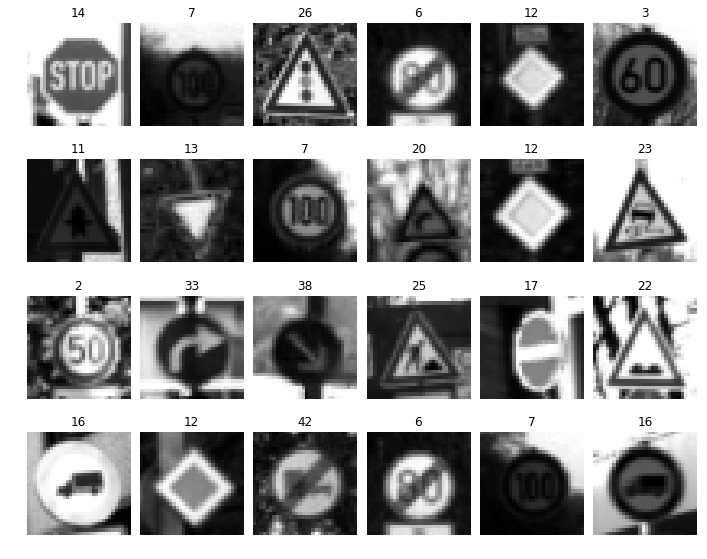

```python
### Preprocess the data here. It is required to normalize the data. Other preprocessing steps could include
### converting to grayscale, etc.
### Feel free to use as many code cells as needed.

# shuffle dataset
def unison_shuffle(x, y, seed=101):
    """
    In-place unison shuffling
    """
    rand_state = np.random.RandomState(seed)
    rand_state.shuffle(x)
    # re-seeding to get the same ordering
    rand_state.seed(seed)
    rand_state.shuffle(y)

def normalize(x):
    return (x - 128) / 128

def grayscale(x):
    return np.sum(x/3, axis=3, keepdims=True)

def preprocess(x):
    return normalize(grayscale(x))

# Testing grayscaling
gray = grayscale(X_valid)
plot_data(gray, y_valid, channel='gray')
```

```python
### Preprocessing Data
prev_mean = np.mean(X_train)
print("Training data shape before preprocessing: ", X_train.shape)
print("Training data mean before preprocessing: ", prev_mean)
X_train = preprocess(X_train)
X_valid = preprocess(X_valid)
X_test  = preprocess(X_test)
proc_mean = np.mean(X_train)

print("Training data shape after preprocessing: ", X_train.shape)
print("Training data mean after preprocessing: ", proc_mean)
```

```
Training data shape before preprocessing:  (34799, 32, 32, 3)
Training data mean before preprocessing:  82.677589037
Training data shape after preprocessing:  (34799, 32, 32, 1)
Training data mean after preprocessing:  -0.354081335648
```

### Labeling

```python
import tensorflow as tf
import csv
NUM_CHANNEL = 1

with open( './signnames.csv', 'rt') as f:
    reader = csv.reader(f)
    label_name = list(reader)

x = tf.placeholder(tf.float32, (None, 32, 32, NUM_CHANNEL))
y = tf.placeholder(tf.int32, (None))
keep_prob = tf.placeholder(tf.float32)
one_hot_y = tf.one_hot(y, n_classes)
```

### Model Architecture

```python
from tensorflow.contrib.layers import flatten

def LeNet(x, mu=0, sigma= 0.1):
    # Layer 1: Convolutional. Input = 32x32x3. Output = 28x28x6.
    conv1_W = tf.Variable(tf.truncated_normal(shape=(5, 5, NUM_CHANNEL, 6), mean = mu, stddev = sigma))
    conv1_b = tf.Variable(tf.zeros(6))
    conv1   = tf.nn.conv2d(x, conv1_W, strides=[1, 1, 1, 1], padding='VALID') + conv1_b

    # Activation.
    conv1 = tf.nn.relu(conv1)

    # Pooling. Input = 28x28x6. Output = 14x14x6.
    conv1 = tf.nn.max_pool(conv1, ksize=[1, 2, 2, 1], strides=[1, 2, 2, 1], padding='VALID')

    # Layer 2: Convolutional. Output = 10x10x16.
    conv2_W = tf.Variable(tf.truncated_normal(shape=(5, 5, 6, 16), mean = mu, stddev = sigma))
    conv2_b = tf.Variable(tf.zeros(16))
    conv2   = tf.nn.conv2d(conv1, conv2_W, strides=[1, 1, 1, 1], padding='VALID') + conv2_b

    # Activation.
    conv2 = tf.nn.relu(conv2)

    # Pooling. Input = 10x10x16. Output = 5x5x16.
    conv2 = tf.nn.max_pool(conv2, ksize=[1, 2, 2, 1], strides=[1, 2, 2, 1], padding='VALID')

    # Flatten. Input = 5x5x16. Output = 400.
    fc0   = flatten(conv2)

    # Layer 3: Fully Connected. Input = 400. Output = 120.
    fc1_W = tf.Variable(tf.truncated_normal(shape=(400, 120), mean = mu, stddev = sigma))
    fc1_b = tf.Variable(tf.zeros(120))
    fc1   = tf.matmul(fc0, fc1_W) + fc1_b

    # Activation and drop out
    fc1    = tf.nn.relu(fc1)
    fc1    = tf.nn.dropout(fc1, keep_prob)

    # Layer 4: Fully Connected. Input = 120. Output = 86.
    fc2_W  = tf.Variable(tf.truncated_normal(shape=(120, 86), mean = mu, stddev = sigma))
    fc2_b  = tf.Variable(tf.zeros(86))
    fc2    = tf.matmul(fc1, fc2_W) + fc2_b

    # Activation and drop out
    fc2    = tf.nn.relu(fc2)
    fc2    = tf.nn.dropout(fc2, keep_prob)

    # Layer 5: Fully Connected. Input = 86. Output = 43.
    fc3_W  = tf.Variable(tf.truncated_normal(shape=(86, n_classes), mean = mu, stddev = sigma))
    fc3_b  = tf.Variable(tf.zeros(n_classes))
    logits = tf.matmul(fc2, fc3_W) + fc3_b

    return logits
```

### Train, Validate and Test the Model

A validation set can be used to assess how well the model is performing. A low accuracy on the training and validation sets imply underfitting. A high accuracy on the training set but low accuracy on the validation set implies overfitting.

### Setting up Pipeline

```python
LR = 0.001
EPOCHS = 50
BATCH_SIZE = 128
KEEP_PROB  = 0.5
# Arguments used for tf.truncated_normal, randomly defines variables for the weights and biases for each layer
MU = 0
SIGMA = 0.1
# Saving output graphs in local directory
GRAPH_FILENAME = './img/curr_training_curve.png'

logits = LeNet(x, MU, SIGMA)
cross_entropy = tf.nn.softmax_cross_entropy_with_logits(labels=one_hot_y, logits=logits)
loss_operation = tf.reduce_mean(cross_entropy)
optimizer = tf.train.AdamOptimizer(learning_rate = LR)
training_operation = optimizer.minimize(loss_operation)
```

### Validating

```python
correct_prediction = tf.equal(tf.argmax(logits, 1), tf.argmax(one_hot_y, 1))
accuracy_operation = tf.reduce_mean(tf.cast(correct_prediction, tf.float32))
saver = tf.train.Saver()

def evaluate(X_data, y_data):
    num_examples = len(X_data)
    total_accuracy = 0
    sess = tf.get_default_session()
    for offset in range(0, num_examples, BATCH_SIZE):
        end = offset + BATCH_SIZE
        batch_x, batch_y = X_data[offset:end], y_data[offset:end]
        accuracy = sess.run(accuracy_operation, feed_dict={x: batch_x, y: batch_y, keep_prob: 1.0})
        total_accuracy += (accuracy * len(batch_x))
    return total_accuracy / num_examples
```

### Training

```python
class Plot(object):
    def __init__(self):
        self.train_accuracy_over_epoch = []
        self.valid_accuracy_over_epoch = []

    def plot_graph(self):
        assert len(self.train_accuracy_over_epoch) == len(self.valid_accuracy_over_epoch)
        x = range(len(self.valid_accuracy_over_epoch))
        y1 = self.train_accuracy_over_epoch
        y2 = self.valid_accuracy_over_epoch

        plt.plot(x, y1,'b-', label='Training Accuray')
        plt.plot(x, y2,'r:', label='Validation Accuray')
        # Create empty plot with blank marker containing the extra label
        plt.plot([],[], ' ', label="LEARNING_RATE: {}".format(LR))
        plt.plot([],[], ' ', label="BATCH_SIZE: {}".format(BATCH_SIZE))
        plt.plot([],[], ' ', label="KEEP_PROB: {}".format(KEEP_PROB))
        plt.plot([],[], ' ', label="Mu: {}".format(MU))
        plt.plot([],[], ' ', label="Sigma: {}".format(SIGMA))

        plt.title('Accuracy Over Time', fontsize=12)
        plt.xlabel('Epoch', fontsize=10)
        plt.ylabel('Accuracy', fontsize=10)
        plt.legend(loc='lower right', fontsize=6)
        plt.savefig(GRAPH_FILENAME)
        plt.show()

p = Plot()
```

```
Training...

EPOCH 0 : Training Accuray 25.3%, Validation Accuracy 56.8%
EPOCH 1 : Training Accuray 58.7%, Validation Accuracy 78.5%
EPOCH 2 : Training Accuray 72.5%, Validation Accuracy 84.8%
EPOCH 3 : Training Accuray 78.7%, Validation Accuracy 87.8%
EPOCH 4 : Training Accuray 82.1%, Validation Accuracy 89.6%
EPOCH 5 : Training Accuray 84.7%, Validation Accuracy 91.0%
EPOCH 6 : Training Accuray 86.2%, Validation Accuracy 92.4%
EPOCH 7 : Training Accuray 87.7%, Validation Accuracy 92.3%
EPOCH 8 : Training Accuray 89.1%, Validation Accuracy 93.7%
EPOCH 9 : Training Accuray 90.0%, Validation Accuracy 94.0%
EPOCH 10 : Training Accuray 90.8%, Validation Accuracy 93.7%
EPOCH 11 : Training Accuray 91.6%, Validation Accuracy 94.8%
EPOCH 12 : Training Accuray 92.1%, Validation Accuracy 95.2%
EPOCH 13 : Training Accuray 92.6%, Validation Accuracy 95.1%
EPOCH 14 : Training Accuray 93.1%, Validation Accuracy 95.7%
EPOCH 15 : Training Accuray 93.4%, Validation Accuracy 94.9%
EPOCH 16 : Training Accuray 94.3%, Validation Accuracy 96.1%
EPOCH 17 : Training Accuray 94.4%, Validation Accuracy 95.8%
EPOCH 18 : Training Accuray 94.5%, Validation Accuracy 95.4%
EPOCH 19 : Training Accuray 94.7%, Validation Accuracy 95.9%
EPOCH 20 : Training Accuray 95.1%, Validation Accuracy 95.8%
EPOCH 21 : Training Accuray 95.4%, Validation Accuracy 95.8%
EPOCH 22 : Training Accuray 95.5%, Validation Accuracy 96.6%
EPOCH 23 : Training Accuray 95.5%, Validation Accuracy 96.6%
EPOCH 24 : Training Accuray 95.7%, Validation Accuracy 95.3%
EPOCH 25 : Training Accuray 95.8%, Validation Accuracy 96.2%
EPOCH 26 : Training Accuray 95.9%, Validation Accuracy 96.6%
EPOCH 27 : Training Accuray 95.9%, Validation Accuracy 96.2%
EPOCH 28 : Training Accuray 96.2%, Validation Accuracy 97.0%
EPOCH 29 : Training Accuray 96.6%, Validation Accuracy 96.4%
EPOCH 30 : Training Accuray 96.4%, Validation Accuracy 96.7%
EPOCH 31 : Training Accuray 96.7%, Validation Accuracy 97.0%
EPOCH 32 : Training Accuray 96.6%, Validation Accuracy 96.8%
EPOCH 33 : Training Accuray 96.7%, Validation Accuracy 96.6%
EPOCH 34 : Training Accuray 96.9%, Validation Accuracy 96.5%
EPOCH 35 : Training Accuray 96.8%, Validation Accuracy 96.2%
EPOCH 36 : Training Accuray 96.9%, Validation Accuracy 97.0%
EPOCH 37 : Training Accuray 97.0%, Validation Accuracy 97.1%
EPOCH 38 : Training Accuray 97.0%, Validation Accuracy 97.0%
EPOCH 39 : Training Accuray 97.4%, Validation Accuracy 96.6%
EPOCH 40 : Training Accuray 97.2%, Validation Accuracy 96.3%
EPOCH 41 : Training Accuray 97.1%, Validation Accuracy 96.6%
EPOCH 42 : Training Accuray 97.1%, Validation Accuracy 96.5%
EPOCH 43 : Training Accuray 97.2%, Validation Accuracy 96.8%
EPOCH 44 : Training Accuray 97.3%, Validation Accuracy 97.0%
EPOCH 45 : Training Accuray 97.5%, Validation Accuracy 96.6%
EPOCH 46 : Training Accuray 97.5%, Validation Accuracy 96.6%
EPOCH 47 : Training Accuray 97.6%, Validation Accuracy 96.7%
EPOCH 48 : Training Accuray 97.6%, Validation Accuracy 96.9%
EPOCH 49 : Training Accuray 97.6%, Validation Accuracy 96.9%
```

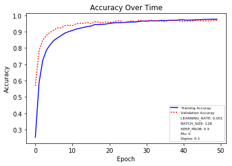

```
Model saved
```

```python
with tf.Session() as sess:
    sess.run(tf.global_variables_initializer())
    num_examples = len(X_train)
    steps_per_epoch = int(num_examples / BATCH_SIZE)
    accum_entropy_loss = 0

    print("Training...\n")
    for i in range(EPOCHS):
        unison_shuffle(X_train, y_train)
        acc_training_accuracy = 0
        for offset in range(0, num_examples, BATCH_SIZE):
            end = offset + BATCH_SIZE
            batch_x, batch_y = X_train[offset:end], y_train[offset:end]
            _, batch_accuracy = sess.run([training_operation, accuracy_operation],
                                         feed_dict={x: batch_x, y: batch_y, keep_prob: KEEP_PROB})
            acc_training_accuracy += batch_accuracy

        avg_training_accuray = acc_training_accuracy / steps_per_epoch
        validation_accuracy  = evaluate(X_valid, y_valid)
        p.train_accuracy_over_epoch.append(avg_training_accuray)
        p.valid_accuracy_over_epoch.append(validation_accuracy)
        print("EPOCH {} : Training Accuray {:.1f}%, Validation Accuracy {:.1f}%".format(i, 100*avg_training_accuray, 100*validation_accuracy))
    p.plot_graph()

    saver.save(sess, './lenet')
    print("Model saved")
```

### Test Model

```python
with tf.Session() as sess:
    saver = tf.train.import_meta_graph('./lenet.meta')
    saver.restore(sess, tf.train.latest_checkpoint('.'))
    test_accuracy = evaluate(X_test, y_test)
    print("Test Set Accuracy {:.1f}%".format(100*test_accuracy))
```

```
Test Set Accuracy 94.2%
```

### Test Result

The accuracy of the model on the test set is **94.2%**. Comparing to the training accuracy of 97.6% and validation accuracy of 96.9%, the model seems to be overfitting. This can be due to the fact that the data set has unequal distribution across all 43 traffic signs. We can improve by generating more images for the scarce labels in the data set.

## Step 3: Test a Model on New Images

To give yourself more insight into how your model is working, download at least five pictures of German traffic signs from the web and use your model to predict the traffic sign type.

You may find `signnames.csv` useful as it contains mappings from the class id (integer) to the actual sign name.

### Load and Output the Images

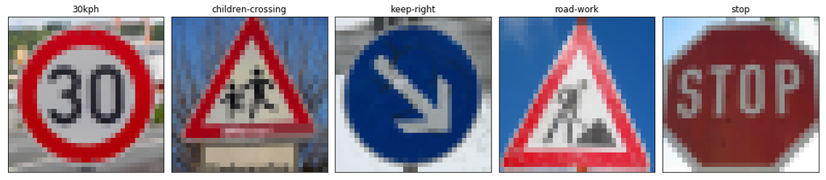

```python
### Load the images and plot them here.
### Feel free to use as many code cells as needed.
import matplotlib.image as mpimg
import cv2

downloaded_img_names = ['30kph','children-crossing','keep-right','road-work','stop']
X_download = []
for name in downloaded_img_names:
    filepath = './downloaded_img/' + name + '.jpg'
    image = (mpimg.imread(filepath))
    X_download.append(cv2.resize(image, (32,32), interpolation=cv2.INTER_AREA))


fig, axes = plt.subplots(1, 5, figsize=(20, 13), subplot_kw={'xticks': [], 'yticks': []})
fig.subplots_adjust(hspace=0.3, wspace=0.05)

for ax, i in zip(axes.flat, range(5)):
    ax.imshow(X_download[i])
    ax.set_title(downloaded_img_names[i])

plt.show()
```

### Predict the Sign Type for Each Image

```python
### Run the predictions here and use the model to output the prediction for each image.
### Make sure to pre-process the images with the same pre-processing pipeline used earlier.
### Feel free to use as many code cells as needed.

X_download = preprocess(np.array(X_download))
y_download = np.array([1, 28, 38, 25, 14])

X_download.shape

predict_operation = tf.nn.top_k(tf.nn.softmax(logits), k=5)

with tf.Session() as sess:
    saver.restore(sess, tf.train.latest_checkpoint('.'))
    prob, indices = sess.run(predict_operation, feed_dict={x: X_download, y: y_download, keep_prob: 1.0})
#     print(scores, indices)
    for i, image in enumerate(X_download):
        corr_label = label_name[y_download[i]+1]
        print("Image", i + 1, "- correct label:", corr_label)
        for j in range(5):
            percent = prob[i][j] * 100
            label   = label_name[indices[i][j] + 1]
            print('{:9.2f}%   {}'.format(percent, label[1]))
#     print("Accuracy on Downloaded Images {:.1f}%".format(100*test_accuracy))
```

```
Image 1 - correct label: ['1', 'Speed limit (30km/h)']
   100.00%   Speed limit (30km/h)
     0.00%   Speed limit (20km/h)
     0.00%   Speed limit (70km/h)
     0.00%   Stop
     0.00%   End of all speed and passing limits
Image 2 - correct label: ['28', 'Children crossing']
    83.90%   Dangerous curve to the right
    14.15%   Road work
     1.10%   Keep right
     0.34%   General caution
     0.29%   Children crossing
Image 3 - correct label: ['38', 'Keep right']
   100.00%   Keep right
     0.00%   No passing
     0.00%   Speed limit (20km/h)
     0.00%   Speed limit (30km/h)
     0.00%   Speed limit (50km/h)
Image 4 - correct label: ['25', 'Road work']
   100.00%   Road work
     0.00%   Dangerous curve to the right
     0.00%   Bicycles crossing
     0.00%   Slippery road
     0.00%   Right-of-way at the next intersection
Image 5 - correct label: ['14', 'Stop']
    49.67%   Stop
    24.19%   Road work
     6.29%   Turn right ahead
     6.17%   Turn left ahead
     3.38%   Priority road
```

### Analyze Performance

The accuracy on the downloaded image is **80%**.

### Project Writeup

Once you have completed the code implementation, document your results in a project writeup using this [template](https://github.com/udacity/CarND-Traffic-Sign-Classifier-Project/blob/master/writeup_template.md) as a guide. The writeup can be in a markdown or pdf file.